# Cars4U- Used Car Price Prediction

# Objective

To explore and visualize the dataset, build a linear regression model to predict the prices of used cars, and generate a set of insights and recommendations that will help the business.

# Key Requirement

come up with a pricing model that can effectively predict the price of used cars and can help the business in devising profitable strategies using differential pricing

# Data Dictionary

The data contains the different attributes of used cars sold in different locations. The detailed data dictionary is given below.

1. S.No.: Serial number
2. Name: Name of the car which includes brand name and model name
3. Location: Location in which the car is being sold or is available for purchase (cities)
4. Year: Manufacturing year of the car
5. Kilometers_driven: The total kilometers (a unit used to measure length or distance) driven in the car by the previous owner(s)
6. Fuel_Type: The type of fuel used by the car (Petrol, Diesel, Electric, CNG, LPG)
7. Transmission: The type of transmission used by the car (Automatic/Manual)
8. Owner: Type of ownership
9. Mileage: The standard mileage offered by the car company in kmpl or km/kg
10. Engine: The displacement volume of the engine in CC
11. Power: The maximum power of the engine in bhp
12. Seats: The number of seats in the car
13. New_Price: The price of a new car of the same model in INR Lakhs (1 Lakh INR = 100,000 INR)
14. Price: The price of the used car in INR Lakhs

# Libraries to help with reading and manipulating data and build model

```python
import numpy as np
import pandas as pd
# Libraries to help with data visualization
import matplotlib.pyplot as plt
import seaborn as sns

import warnings
warnings.filterwarnings('ignore')

import missingno as mnso
# Libraries to help with data visualization
%matplotlib inline

# to split the data into train and test
from sklearn.model_selection import train_test_split

# to build linear regression_model
from sklearn.linear_model import LinearRegression

# to check model performance
from sklearn.metrics import mean_absolute_error, mean_squared_error, r2_score

# Removes the limit from the number of displayed columns and rows.
pd.set_option('display.max_columns', None)
pd.set_option('display.max_rows', 100)
```

# Reading Data from csv

```python
#To connect to Google drive and use Google Colab

from google.colab import drive
drive.mount('/content/drive')
```

```python
CarDataFromFile=pd.read_csv('/content/drive/MyDrive/used_cars_data.csv')

## Let creating working copy
carsData=CarDataFromFile.copy()
```

# Data Sanity Check

```python
# to check shape of data
print(f'In Cars Data set there are {carsData.shape[0]} rows and {carsData.shape[1]} columns')
```

```
In Cars Data set there are 7253 rows and 14 columns
```

```python
np.random.seed(1)
carsData.sample(10)
```

|  | S.No. | Name | Location | Year | Kilometers_Driven | Fuel_Type | Transmission | Owner_Type | Mileage | Engine | Power | Seats | New_Price | Price |
| --- | --- | --- | --- | --- | --- | --- | --- | --- | --- | --- | --- | --- | --- | --- |
| 2397 | 2397 | Ford EcoSport 1.5 Petrol Trend | Kolkata | 2016 | 21460 | Petrol | Manual | First | 17.0 kmpl | 1497 CC | 121.36 bhp | 5.0 | 9.47 | 6.00 |
| 3777 | 3777 | Maruti Wagon R VXI 1.2 | Kochi | 2015 | 49818 | Petrol | Manual | First | 21.5 kmpl | 1197 CC | 81.80 bhp | 5.0 | 5.44 | 4.11 |
| 4425 | 4425 | Ford Endeavour 4x2 XLT | Hyderabad | 2007 | 130000 | Diesel | Manual | First | 13.1 kmpl | 2499 CC | 141 bhp | 7.0 | 35.29 | 6.00 |
| 3661 | 3661 | Mercedes-Benz E-Class E250 CDI Avantgrade | Coimbatore | 2016 | 39753 | Diesel | Automatic | First | 13.0 kmpl | 2143 CC | 201.1 bhp | 5.0 | 86.97 | 35.28 |
| 4514 | 4514 | Hyundai Xcent 1.2 Kappa AT SX Option | Kochi | 2016 | 45560 | Petrol | Automatic | First | 16.9 kmpl | 1197 CC | 82 bhp | 5.0 | 8.23 | 6.34 |
| 599 | 599 | Toyota Innova Crysta 2.8 ZX AT | Coimbatore | 2019 | 40674 | Diesel | Automatic | First | 11.36 kmpl | 2755 CC | 171.5 bhp | 7.0 | 28.05 | 24.82 |
| 186 | 186 | Mercedes-Benz E-Class E250 CDI Avantgrade | Bangalore | 2014 | 37382 | Diesel | Automatic | First | 13.0 kmpl | 2143 CC | 201.1 bhp | 5.0 | 86.97 | 32.00 |
| 305 | 305 | Audi A6 2011-2015 2.0 TDI Premium Plus | Kochi | 2014 | 61726 | Diesel | Automatic | First | 17.68 kmpl | 1968 CC | 174.33 bhp | 5.0 | 67.10 | 20.77 |
| 4582 | 4582 | Hyundai i20 1.2 Magna | Kolkata | 2011 | 36000 | Petrol | Manual | First | 18.5 kmpl | 1197 CC | 80 bhp | 5.0 | 10.25 | 2.50 |
| 5434 | 5434 | Honda WR-V Edge Edition i-VTEC S | Kochi | 2019 | 13913 | Petrol | Manual | First | 17.5 kmpl | 1199 CC | 88.7 bhp | 5.0 | 9.36 | 8.20 |

```python
carsData.info()
```

```
<class 'pandas.core.frame.DataFrame'>
RangeIndex: 7253 entries, 0 to 7252
Data columns (total 14 columns):
 #   Column             Non-Null Count  Dtype
---  ------             --------------  -----
 0   S.No.              7253 non-null   int64
 1   Name               7253 non-null   object
 2   Location           7253 non-null   object
 3   Year               7253 non-null   int64
 4   Kilometers_Driven  7253 non-null   int64
 5   Fuel_Type          7253 non-null   object
 6   Transmission       7253 non-null   object
 7   Owner_Type         7253 non-null   object
 8   Mileage            7251 non-null   object
 9   Engine             7207 non-null   object
 10  Power              7078 non-null   object
 11  Seats              7200 non-null   float64
 12  New_Price          7253 non-null   float64
 13  Price              6019 non-null   float64
dtypes: float64(3), int64(3), object(8)
memory usage: 793.4+ KB
```

```python
carsData.describe(include='all').T
```

|  | count | unique | top | freq | mean | std | min | 25% | 50% | 75% | max |
| --- | --- | --- | --- | --- | --- | --- | --- | --- | --- | --- | --- |
| S.No. | 7253.0 | NaN | NaN | NaN | 3626.0 | 2093.905084 | 0.0 | 1813.0 | 3626.0 | 5439.0 | 7252.0 |
| Name | 7253 | 2041 | Mahindra XUV500 W8 2WD | 55 | NaN | NaN | NaN | NaN | NaN | NaN | NaN |
| Location | 7253 | 11 | Mumbai | 949 | NaN | NaN | NaN | NaN | NaN | NaN | NaN |
| Year | 7253.0 | NaN | NaN | NaN | 2013.365366 | 3.254421 | 1996.0 | 2011.0 | 2014.0 | 2016.0 | 2019.0 |
| Kilometers_Driven | 7253.0 | NaN | NaN | NaN | 58699.063146 | 84427.720583 | 171.0 | 34000.0 | 53416.0 | 73000.0 | 6500000.0 |
| Fuel_Type | 7253 | 5 | Diesel | 3852 | NaN | NaN | NaN | NaN | NaN | NaN | NaN |
| Transmission | 7253 | 2 | Manual | 5204 | NaN | NaN | NaN | NaN | NaN | NaN | NaN |
| Owner_Type | 7253 | 4 | First | 5952 | NaN | NaN | NaN | NaN | NaN | NaN | NaN |
| Mileage | 7251 | 450 | 17.0 kmpl | 207 | NaN | NaN | NaN | NaN | NaN | NaN | NaN |
| Engine | 7207 | 150 | 1197 CC | 732 | NaN | NaN | NaN | NaN | NaN | NaN | NaN |
| Power | 7078 | 385 | 74 bhp | 280 | NaN | NaN | NaN | NaN | NaN | NaN | NaN |
| Seats | 7200.0 | NaN | NaN | NaN | 5.279722 | 0.81166 | 0.0 | 5.0 | 5.0 | 5.0 | 10.0 |
| New_Price | 7253.0 | NaN | NaN | NaN | 21.307322 | 24.256314 | 3.91 | 7.88 | 11.3 | 21.69 | 375.0 |
| Price | 6019.0 | NaN | NaN | NaN | 9.479468 | 11.187917 | 0.44 | 3.5 | 5.64 | 9.95 | 160.0 |

```python
# To check if data set has any duplicate rows
carsData.duplicated().sum()
```

```
0
```

```python
# Let us drop S. No column
carsData.drop('S.No.',axis=1,inplace=True)
```

```python
carsData.reset_index(inplace=True,drop=True)
```

```python
carsData.isnull().sum().sort_values(ascending=False)
```

```
Price                1234
Power                 175
Seats                  53
Engine                 46
Mileage                 2
Name                    0
Location                0
Year                    0
Kilometers_Driven       0
Fuel_Type               0
Transmission            0
Owner_Type              0
New_Price               0
dtype: int64
```

Price is going to be our target variable hence we will drop all rows which have Price data Missing.

```python
carsData.dropna(subset=['Price'], inplace=True)
```

```python
carsData.isnull().sum()
```

```
Name                   0
Location               0
Year                   0
Kilometers_Driven      0
Fuel_Type              0
Transmission           0
Owner_Type             0
Mileage                2
Engine                36
Power                143
Seats                 42
New_Price              0
Price                  0
dtype: int64
```

# Data Exploration : High Level Summary

# Treating Mileage , Engine and Power

1. These three column should be numeric but they are appearing as Objects .Lets explore it

```python
carsData[['Mileage','Power','Engine']].tail(2000)
```

|  | Mileage | Power | Engine |
| --- | --- | --- | --- |
| 4019 | 21.9 kmpl | 88.76 bhp | 1396 CC |
| 4020 | 25.2 kmpl | 74 bhp | 1248 CC |
| 4021 | 11.7 kmpl | 178 bhp | 1796 CC |
| 4022 | 14.28 kmpl | 138.03 bhp | 1798 CC |
| 4023 | 22.32 kmpl | 126.32 bhp | 1582 CC |
| ... | ... | ... | ... |
| 6014 | 28.4 kmpl | 74 bhp | 1248 CC |
| 6015 | 24.4 kmpl | 71 bhp | 1120 CC |
| 6016 | 14.0 kmpl | 112 bhp | 2498 CC |
| 6017 | 18.9 kmpl | 67.1 bhp | 998 CC |
| 6018 | 25.44 kmpl | 57.6 bhp | 936 CC |

2000 rows × 3 columns

```python
 ## Function covertToNumeric will spllit data in incomming DF based on  separator  " "
 ## and it  will  return 0th position as this contains actual number  and index 1 , 2 and further contains other strings.
```

```python
def covertToNumeric(colname):
  if isinstance(colname, str):
   return float((colname.split(' ')[0]))
  else:
    return np.nan
```

```python
position_cols=['Mileage','Power','Engine']
```

```python
# For all three three columns lets call covertToNumeric Function which will remove all strings from it and then return it as Float
# string likes  lkm/kg', 'kmpl'  can be seen in  columns Mileage , Engine and Power . Fucntion will remove theese string and and convert first part  to Float.
for colname in position_cols :
  carsData[colname]=carsData[colname].apply(covertToNumeric)
```

```python
carsData.info()
```

```
<class 'pandas.core.frame.DataFrame'>
Int64Index: 6019 entries, 0 to 6018
Data columns (total 13 columns):
 #   Column             Non-Null Count  Dtype
---  ------             --------------  -----
 0   Name               6019 non-null   object
 1   Location           6019 non-null   object
 2   Year               6019 non-null   int64
 3   Kilometers_Driven  6019 non-null   int64
 4   Fuel_Type          6019 non-null   object
 5   Transmission       6019 non-null   object
 6   Owner_Type         6019 non-null   object
 7   Mileage            6017 non-null   float64
 8   Engine             5983 non-null   float64
 9   Power              5876 non-null   float64
 10  Seats              5977 non-null   float64
 11  New_Price          6019 non-null   float64
 12  Price              6019 non-null   float64
dtypes: float64(6), int64(2), object(5)
memory usage: 658.3+ KB
```

We can see Engine,Power,Milage column's data tpe is changed to Float. let's again check statistical Summary .

```python
carsData.describe(include='all').T
```

|  | count | unique | top | freq | mean | std | min | 25% | 50% | 75% | max |
| --- | --- | --- | --- | --- | --- | --- | --- | --- | --- | --- | --- |
| Name | 6019 | 1876 | Mahindra XUV500 W8 2WD | 49 | NaN | NaN | NaN | NaN | NaN | NaN | NaN |
| Location | 6019 | 11 | Mumbai | 790 | NaN | NaN | NaN | NaN | NaN | NaN | NaN |
| Year | 6019.0 | NaN | NaN | NaN | 2013.358199 | 3.269742 | 1998.0 | 2011.0 | 2014.0 | 2016.0 | 2019.0 |
| Kilometers_Driven | 6019.0 | NaN | NaN | NaN | 58738.380296 | 91268.843206 | 171.0 | 34000.0 | 53000.0 | 73000.0 | 6500000.0 |
| Fuel_Type | 6019 | 5 | Diesel | 3205 | NaN | NaN | NaN | NaN | NaN | NaN | NaN |
| Transmission | 6019 | 2 | Manual | 4299 | NaN | NaN | NaN | NaN | NaN | NaN | NaN |
| Owner_Type | 6019 | 4 | First | 4929 | NaN | NaN | NaN | NaN | NaN | NaN | NaN |
| Mileage | 6017.0 | NaN | NaN | NaN | 18.134961 | 4.582289 | 0.0 | 15.17 | 18.15 | 21.1 | 33.54 |
| Engine | 5983.0 | NaN | NaN | NaN | 1621.27645 | 601.355233 | 72.0 | 1198.0 | 1493.0 | 1984.0 | 5998.0 |
| Power | 5876.0 | NaN | NaN | NaN | 113.25305 | 53.874957 | 34.2 | 75.0 | 97.7 | 138.1 | 560.0 |
| Seats | 5977.0 | NaN | NaN | NaN | 5.278735 | 0.80884 | 0.0 | 5.0 | 5.0 | 5.0 | 10.0 |
| New_Price | 6019.0 | NaN | NaN | NaN | 21.499855 | 24.332922 | 3.91 | 7.88 | 11.3 | 21.77 | 375.0 |
| Price | 6019.0 | NaN | NaN | NaN | 9.479468 | 11.187917 | 0.44 | 3.5 | 5.64 | 9.95 | 160.0 |

# Analyzing Car Name column

1. Looking at data in Name column we can see that it conains Company Name , Model and some details in single fields.
2. Let us first check value count for Name column to see how data is distubuted across this column

```python
CarNameDf=carsData['Name'].value_counts().sort_values(ascending =False)
```

```python
CarNameDf.head(100)
```

```
Mahindra XUV500 W8 2WD                        49
Maruti Swift VDI                              45
Honda City 1.5 S MT                           34
Maruti Swift Dzire VDI                        34
Maruti Swift VDI BSIV                         31
Maruti Ritz VDi                               30
Hyundai i10 Sportz                            30
Toyota Fortuner 3.0 Diesel                    29
Honda Amaze S i-Dtech                         27
Hyundai Grand i10 Sportz                      27
Maruti Ertiga VDI                             25
Honda Brio S MT                               25
Honda City 1.5 V MT                           24
Maruti Wagon R VXI                            23
Hyundai Verna 1.6 SX                          23
Maruti Wagon R LXI                            22
Maruti Alto LXi                               21
Hyundai EON Era Plus                          20
Maruti Ertiga ZDI                             20
Skoda Superb Elegance 1.8 TSI AT              20
BMW 3 Series 320d                             20
Maruti Alto 800 LXI                           20
Toyota Fortuner 4x2 AT                        19
Hyundai i10 Magna 1.2                         19
Maruti Celerio VXI AT                         19
Maruti Swift Dzire VXI                        18
Volkswagen Polo 1.5 TDI Highline              18
Volkswagen Polo 1.2 MPI Highline              18
Renault KWID RXT                              18
Hyundai i20 1.2 Magna                         18
Volkswagen Vento Diesel Highline              18
Maruti Wagon R LXI CNG                        18
Ford Figo Diesel EXI                          17
Audi A4 2.0 TDI                               17
Ford Figo Diesel Titanium                     17
Renault Duster 110PS Diesel RxZ               17
Volkswagen Polo Diesel Comfortline 1.2L       17
Ford Ecosport 1.5 DV5 MT Titanium Optional    16
Hyundai Grand i10 AT Asta                     16
Maruti Swift Dzire VDi                        16
```

[output cut: 46 more lines]

```
Maruti Swift VXI BSIV                         12
Hyundai i20 1.2 Sportz                        12
Volkswagen Vento 1.5 TDI Highline             12
Hyundai Verna 1.6 SX VTVT (O)                 11
Volkswagen Polo Diesel Highline 1.2L          11
Hyundai i20 Asta Option 1.2                   11
Maruti Wagon R VXI BS IV                      11
Hyundai Grand i10 Asta                        11
Maruti Alto 800 2016-2019 LXI                 11
Chevrolet Beat LS                             11
Ford Figo Petrol ZXI                          11
Maruti Swift Dzire VXi                        11
Volkswagen Polo Diesel Trendline 1.2L         11
Honda City i DTEC VX                          11
Name: Name, dtype: int64
```

There are total 1876 Names (combinations of Company Name and Model Name occuring in Data set ) with maximum Cars being sold by Mahindra of model XUV500 W8 2WD followed by Maruti Swift VDI .

# Splitting Car Name Column

1. Let us split Name column based on Space and check value counts for company name and model individually .
2. Based on counts we will decide whether we shoudl use Name as single field or should we use newly created fields .

```python
# On Primary Inspection we found that  Wagan R has some space Land Rover was treated as separte hence first remove space in that.
carsData['Name']=carsData['Name'].replace("Wagon R","WaganR",regex=True)
carsData['Name']=carsData['Name'].replace("Land Rover","LandRover",regex=True)
```

```python
# Lets Split and expand it to three columns, we  are inerested in First two columns i.e Company Name and Model but we want to separate model with other details hence splitting it in three columns
CarCompanyNameModel=carsData['Name'].str.split(" ",n=2,expand=True)
```

```python
CarCompanyNameModel.columns=['CompanyName','Model','Ignore']
```

```python
CarCompanyNameModel.head(100)
```

|  | CompanyName | Model | Ignore |
| --- | --- | --- | --- |
| 0 | Maruti | WaganR | LXI CNG |
| 1 | Hyundai | Creta | 1.6 CRDi SX Option |
| 2 | Honda | Jazz | V |
| 3 | Maruti | Ertiga | VDI |
| 4 | Audi | A4 | New 2.0 TDI Multitronic |
| 5 | Hyundai | EON | LPG Era Plus Option |
| 6 | Nissan | Micra | Diesel XV |
| 7 | Toyota | Innova | Crysta 2.8 GX AT 8S |
| 8 | Volkswagen | Vento | Diesel Comfortline |
| 9 | Tata | Indica | Vista Quadrajet LS |
| 10 | Maruti | Ciaz | Zeta |
| 11 | Honda | City | 1.5 V AT Sunroof |
| 12 | Maruti | Swift | VDI BSIV |
| 13 | LandRover | Range | Rover 2.2L Pure |
| 14 | LandRover | Freelander | 2 TD4 SE |
| 15 | Mitsubishi | Pajero | Sport 4X4 |
| 16 | Honda | Amaze | S i-Dtech |
| 17 | Maruti | Swift | DDiS VDI |
| 18 | Renault | Duster | 85PS Diesel RxL Plus |
| 19 | Mercedes-Benz | New | C-Class C 220 CDI BE Avantgare |
| 20 | BMW | 3 | Series 320d |
| 21 | Maruti | S | Cross DDiS 200 Alpha |
| 22 | Audi | A6 | 2011-2015 35 TFSI Technology |
| 23 | Hyundai | i20 | 1.2 Magna |
| 24 | Volkswagen | Vento | Petrol Highline AT |
| 25 | Honda | City | Corporate Edition |
| 26 | Nissan | Micra | Diesel XV |
| 27 | Maruti | Alto | K10 2010-2014 VXI |
| 28 | Honda | WRV | i-VTEC VX |
| 29 | Toyota | Innova | 2.5 V Diesel 7-seater |

[output cut: 70 more lines]

Check how many cars of which company name are present in data set

```python
CompanyNameCounts=CarCompanyNameModel['CompanyName'].value_counts()
CompanyNameCounts.head(50)
```

```
Maruti           1211
Hyundai          1107
Honda             608
Toyota            411
Mercedes-Benz     318
Volkswagen        315
Ford              300
Mahindra          272
BMW               267
Audi              236
Tata              186
Skoda             173
Renault           145
Chevrolet         121
Nissan             91
LandRover          60
Jaguar             40
Fiat               28
Mitsubishi         27
Mini               26
Volvo              21
Porsche            18
Jeep               15
Datsun             13
Force               3
ISUZU               2
Smart               1
Ambassador          1
Isuzu               1
Bentley             1
Lamborghini         1
Name: CompanyName, dtype: int64
```

We can see that Maximum occurance is of company Name Maruti and Hundai which depicts that maximum cars are being sold belong to Maruti and Hundai

Check how many sold cars of which Model are present in data set

```python
# To store Details of Model and it's count
ModelCounts=CarCompanyNameModel['Model'].value_counts().sort_values(ascending=False)
```

```python
ModelCounts.head(100)
```

```
Swift         353
City          270
i20           247
Verna         170
Innova        164
i10           156
Grand         156
WaganR        154
Polo          151
Alto          143
XUV500        113
Vento         107
Amaze         106
New           102
Fortuner      101
Figo          101
3              98
Creta          93
E-Class        88
Duster         83
Santro         78
A4             78
Ertiga         75
Ciaz           71
5              68
Corolla        68
Ritz           64
Baleno         63
EON            61
Scorpio        61
Etios          61
Brio           60
Xcent          59
Celerio        58
Jazz           58
Ecosport       53
A6             49
Superb         49
Rapid          47
Beat           46
```

[output cut: 46 more lines]

```
Ikon           15
Compass        15
Aveo           14
X3             14
Elite          14
KUV            14
Ssangyong      13
7              13
CLA            13
Linea          12
B              12
Discovery      12
800            12
Optra          12
Name: Model, dtype: int64
```

When we checked top 100 we could see maximum times there is entry for model Swift

## Treatment for Car Name Column

1. We have analyzed Car Name as single string and also by separing it between Company name and Model .
2. When we analyzed Name as single field there are 1876 unique combinations
3. Hence For this analysis we will first add Company Name and Model as new columns in carsData data Frame .
4. Then we checked counts for Company Name and Model ,they are also high so we will have take some cut off and based on that we will term all company Name and Model below that cut off as some random name say "Other"
5. Based on values in Company Name counts and ModelCounts we can take cut of Company Name and Model .
6. To code items as "Other " first For both Company Name and Model we will have to create Lookup list one for Company Name and one for Model .
7. Next we will write Function which will check if Company Name/Model contains item from Lookup table if yes then keep value as is else replace with "Other"

```python
# Adding Company Name and Model to carsData
carsData['CompanyName']=CarCompanyNameModel['CompanyName']
carsData['Model']=CarCompanyNameModel['Model']
```

```python
## Lookup  Master for Company Name  and Model which will be top 50 and 50 values Company Names and Model Name respectively
Lookup_Master_companyName = CompanyNameCounts[CompanyNameCounts.values >= 50].index.tolist()
Lookup_Master_companyModel = ModelCounts[ModelCounts.values >= 50].index.tolist()
```

```python
def LookUpBasedConverition(inputDF,lookup,CName):
  car_temp=[]

  for i in range(inputDF.shape[0]):
    check = 0  # to see of variable in data frame is matching with Lookup field
    for item in lookup:
        if item in inputDF[CName].values[i] and check == 0:
            car_temp.append(item)
            check = 1
    if check == 0:
        car_temp.append("Others")
  inputDF[CName +"_revised"] = [item for item in car_temp]
  del car_temp
```

```python
carsData.describe(include='all').T
```

|  | count | unique | top | freq | mean | std | min | 25% | 50% | 75% | max |
| --- | --- | --- | --- | --- | --- | --- | --- | --- | --- | --- | --- |
| Name | 6019 | 1876 | Mahindra XUV500 W8 2WD | 49 | NaN | NaN | NaN | NaN | NaN | NaN | NaN |
| Location | 6019 | 11 | Mumbai | 790 | NaN | NaN | NaN | NaN | NaN | NaN | NaN |
| Year | 6019.0 | NaN | NaN | NaN | 2013.358199 | 3.269742 | 1998.0 | 2011.0 | 2014.0 | 2016.0 | 2019.0 |
| Kilometers_Driven | 6019.0 | NaN | NaN | NaN | 58738.380296 | 91268.843206 | 171.0 | 34000.0 | 53000.0 | 73000.0 | 6500000.0 |
| Fuel_Type | 6019 | 5 | Diesel | 3205 | NaN | NaN | NaN | NaN | NaN | NaN | NaN |
| Transmission | 6019 | 2 | Manual | 4299 | NaN | NaN | NaN | NaN | NaN | NaN | NaN |
| Owner_Type | 6019 | 4 | First | 4929 | NaN | NaN | NaN | NaN | NaN | NaN | NaN |
| Mileage | 6017.0 | NaN | NaN | NaN | 18.134961 | 4.582289 | 0.0 | 15.17 | 18.15 | 21.1 | 33.54 |
| Engine | 5983.0 | NaN | NaN | NaN | 1621.27645 | 601.355233 | 72.0 | 1198.0 | 1493.0 | 1984.0 | 5998.0 |
| Power | 5876.0 | NaN | NaN | NaN | 113.25305 | 53.874957 | 34.2 | 75.0 | 97.7 | 138.1 | 560.0 |
| Seats | 5977.0 | NaN | NaN | NaN | 5.278735 | 0.80884 | 0.0 | 5.0 | 5.0 | 5.0 | 10.0 |
| New_Price | 6019.0 | NaN | NaN | NaN | 21.499855 | 24.332922 | 3.91 | 7.88 | 11.3 | 21.77 | 375.0 |
| Price | 6019.0 | NaN | NaN | NaN | 9.479468 | 11.187917 | 0.44 | 3.5 | 5.64 | 9.95 | 160.0 |
| CompanyName | 6019 | 31 | Maruti | 1211 | NaN | NaN | NaN | NaN | NaN | NaN | NaN |
| Model | 6019 | 214 | Swift | 353 | NaN | NaN | NaN | NaN | NaN | NaN | NaN |

```python
## calling LookUpBasedConverition which will check for Company Name in row and if it is not from Top 50 then will replace with word Other
LookUpBasedConverition(carsData,Lookup_Master_companyName,'CompanyName')
```

```python
## calling LookUpBasedConverition which will check for Model name in row and if it is not from Top 50 then will replace with word Other
LookUpBasedConverition(carsData,Lookup_Master_companyModel,'Model')
```

```python
carsData.describe(include='all').T
```

|  | count | unique | top | freq | mean | std | min | 25% | 50% | 75% | max |
| --- | --- | --- | --- | --- | --- | --- | --- | --- | --- | --- | --- |
| Name | 6019 | 1876 | Mahindra XUV500 W8 2WD | 49 | NaN | NaN | NaN | NaN | NaN | NaN | NaN |
| Location | 6019 | 11 | Mumbai | 790 | NaN | NaN | NaN | NaN | NaN | NaN | NaN |
| Year | 6019.0 | NaN | NaN | NaN | 2013.358199 | 3.269742 | 1998.0 | 2011.0 | 2014.0 | 2016.0 | 2019.0 |
| Kilometers_Driven | 6019.0 | NaN | NaN | NaN | 58738.380296 | 91268.843206 | 171.0 | 34000.0 | 53000.0 | 73000.0 | 6500000.0 |
| Fuel_Type | 6019 | 5 | Diesel | 3205 | NaN | NaN | NaN | NaN | NaN | NaN | NaN |
| Transmission | 6019 | 2 | Manual | 4299 | NaN | NaN | NaN | NaN | NaN | NaN | NaN |
| Owner_Type | 6019 | 4 | First | 4929 | NaN | NaN | NaN | NaN | NaN | NaN | NaN |
| Mileage | 6017.0 | NaN | NaN | NaN | 18.134961 | 4.582289 | 0.0 | 15.17 | 18.15 | 21.1 | 33.54 |
| Engine | 5983.0 | NaN | NaN | NaN | 1621.27645 | 601.355233 | 72.0 | 1198.0 | 1493.0 | 1984.0 | 5998.0 |
| Power | 5876.0 | NaN | NaN | NaN | 113.25305 | 53.874957 | 34.2 | 75.0 | 97.7 | 138.1 | 560.0 |
| Seats | 5977.0 | NaN | NaN | NaN | 5.278735 | 0.80884 | 0.0 | 5.0 | 5.0 | 5.0 | 10.0 |
| New_Price | 6019.0 | NaN | NaN | NaN | 21.499855 | 24.332922 | 3.91 | 7.88 | 11.3 | 21.77 | 375.0 |
| Price | 6019.0 | NaN | NaN | NaN | 9.479468 | 11.187917 | 0.44 | 3.5 | 5.64 | 9.95 | 160.0 |
| CompanyName | 6019 | 31 | Maruti | 1211 | NaN | NaN | NaN | NaN | NaN | NaN | NaN |
| Model | 6019 | 214 | Swift | 353 | NaN | NaN | NaN | NaN | NaN | NaN | NaN |
| CompanyName_revised | 6019 | 17 | Maruti | 1211 | NaN | NaN | NaN | NaN | NaN | NaN | NaN |
| Model_revised | 6019 | 37 | Others | 1916 | NaN | NaN | NaN | NaN | NaN | NaN | NaN |

Converting Fuel Type , owner Type , Location,Transmission to Categorical Variable

# Converting Fuel Type , owner Type , Location,Transmission to Categorical Variable

```python
carsData['Fuel_Type']=carsData['Fuel_Type'].astype('category')
carsData['Owner_Type']=carsData['Owner_Type'].astype('category')
carsData['Transmission']=carsData['Transmission'].astype('category')
carsData['Location']=carsData['Location'].astype('category')
```

```python
carsData.info()
```

```
<class 'pandas.core.frame.DataFrame'>
Int64Index: 6019 entries, 0 to 6018
Data columns (total 17 columns):
 #   Column               Non-Null Count  Dtype
---  ------               --------------  -----
 0   Name                 6019 non-null   object
 1   Location             6019 non-null   category
 2   Year                 6019 non-null   int64
 3   Kilometers_Driven    6019 non-null   int64
 4   Fuel_Type            6019 non-null   category
 5   Transmission         6019 non-null   category
 6   Owner_Type           6019 non-null   category
 7   Mileage              6017 non-null   float64
 8   Engine               5983 non-null   float64
 9   Power                5876 non-null   float64
 10  Seats                5977 non-null   float64
 11  New_Price            6019 non-null   float64
 12  Price                6019 non-null   float64
 13  CompanyName          6019 non-null   object
 14  Model                6019 non-null   object
 15  CompanyName_revised  6019 non-null   object
 16  Model_revised        6019 non-null   object
dtypes: category(4), float64(6), int64(2), object(5)
memory usage: 682.7+ KB
```

# Determine Age of Car . Based on Year of Manufacturing

```python
carsData['Age']=2019-carsData['Year']
 # Post this we will  Drop Year column from Data set
```

# Missing Value Treatment for Seats .Milage ,Engine and Power

```python
# For Milage Mean and Median are around same range hence we can replace missing values with mean or median . We choose mean
carsData['Mileage'].fillna(carsData['Mileage'].mean(),inplace=True)
```

```python
# Engine Data is skewed . Hence Choosing Median Value to replace missing data for Engine
carsData['Engine'].fillna(carsData['Engine'].median(),inplace=True)
```

```python
#Power Data is right skewed hence choosing Median values to replace missing data
carsData['Power'].fillna(carsData['Power'].median(),inplace=True)
```

```python
# Seats have very few missing values and it's mean and median is almost same so we can relace missing values with it's mean
carsData['Seats'].fillna(carsData['Seats'].mean(),inplace=True)
```

```python
carsData.isnull().sum()
```

```
Name                   0
Location               0
Year                   0
Kilometers_Driven      0
Fuel_Type              0
Transmission           0
Owner_Type             0
Mileage                0
Engine                 0
Power                  0
Seats                  0
New_Price              0
Price                  0
CompanyName            0
Model                  0
CompanyName_revised    0
Model_revised          0
Age                    0
dtype: int64
```

# Univariate Alaysis

```python
#Let us  create new data Frame as copy of Orginial  carsDataFrame
dfForModel=carsData.copy()
dfForModel.drop(['CompanyName','Model','Name','Year'],inplace=True,axis=1)
```

```python
## Create List of Numerical columns
from numpy.core import numeric
numericList = dfForModel.dtypes[dfForModel.dtypes!='object'].index
```

Let us Plot Heat map and see corelation between all Numerical columns

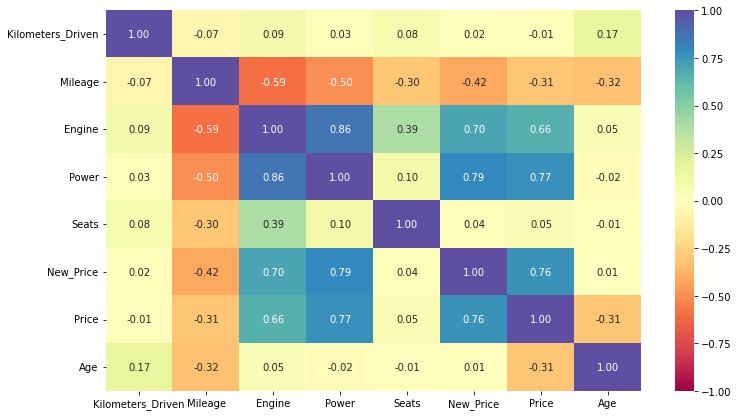

```python
plt.figure(figsize=(12, 7))
sns.heatmap(
    dfForModel[numericList].corr(), annot=True, vmin=-1, vmax=1, fmt=".2f", cmap="Spectral"
)
plt.show()
```

1. We can see price has strong positive co-relation with New price , Engine and Power .
2. Power has very strong co -relation with Engine and new Price and Price
3. Power and Engine have negative co -relation with milage

Lets plot box plot and histplot for all numerical variables using user defined function checkDistribution.

User defined function ,"checkDistribution" will plot Histplot and Box Plot for all numerical columns.In Boxplot we will add showmeans =true to show Mean value , which will help us in comparing mean and median values.

```python
# This Function will  use to  Plot Histplot and Box Plot for all numberical columns  . We will add Lines to show mean and Median
# so we can check skewness of data .
# we will pass data Frame and column name as variables
def checkDistribution(dataframe,columnName):
     plt.figure(figsize=(20,8));
     plt.subplot(1,2,1)
     plt.title("Distribution for Variable "+ columnName, fontsize=15)
     sns.histplot(data=dataframe,x=columnName,kde=True ,bins=15)
     plt.axvline(np.mean(dataframe[columnName]), color='green', linestyle='--') # Add mean to the histogram
     plt.text(np.mean(dataframe[columnName])+0.15,30,'Mean = '+str(round(np.mean(dataframe[columnName]),1)),rotation=90, fontsize=12)
     plt.axvline(np.median(dataframe[columnName]), color='red', linestyle='-') # Add median to the histogram
     plt.text(np.median(dataframe[columnName])+0.15,30,'Median = '+str(round(np.median(dataframe[columnName]),1)),rotation=90, fontsize=12)
     # To plot Bolxplot and showing Mean value
     plt.subplot(1,2,2)
     plt.title("Boxplot for "+ columnName, fontsize=12)
     sns.boxplot(data=dataframe,x=columnName ,showmeans=True )
```

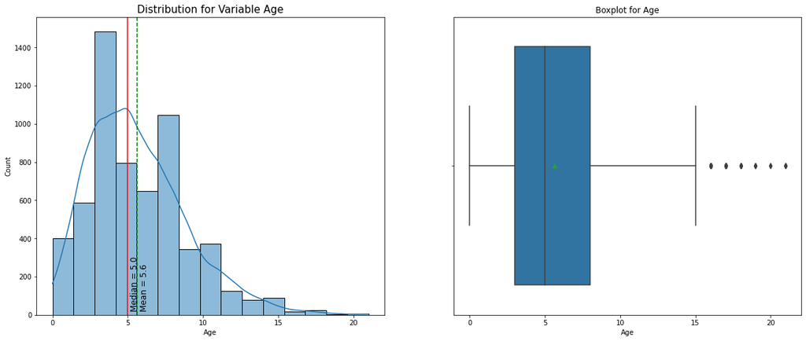

```python
checkDistribution(dfForModel,'Age')
```

We Can see that averange cars are sold within 5 to 5.5.6 year of manufacting .with some outliers where cars Age is more than 15 years .

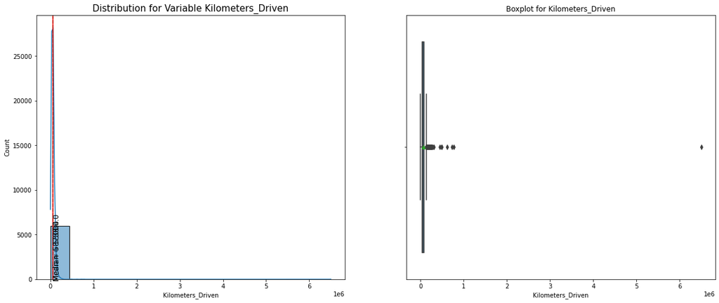

```python
checkDistribution(dfForModel,'Kilometers_Driven')
```

Kms Plots are difficult to visualize and can be seeon as right skewed. Let us convert it to Log values and see how it appears .

```python
dfForModel['Kilometers_Driven' + "_log"] = np.log(dfForModel['Kilometers_Driven'] + 1)
```

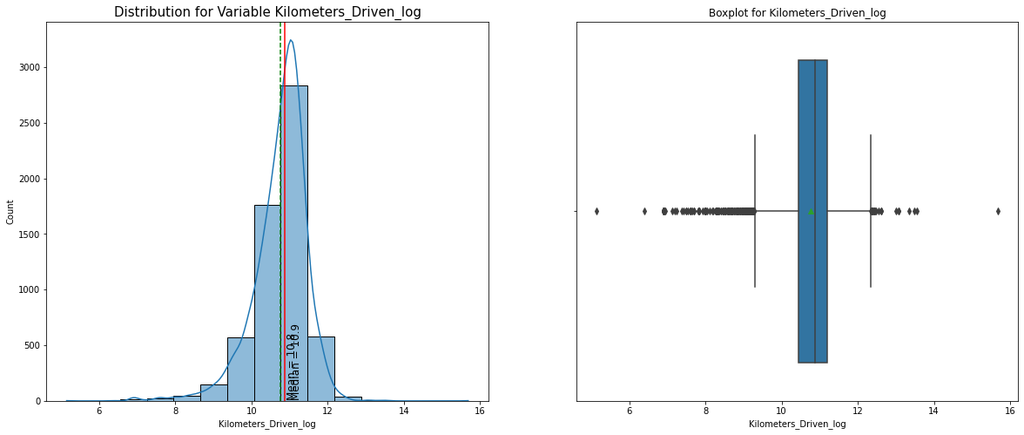

```python
checkDistribution(dfForModel,'Kilometers_Driven_log')
```

We can clearly see that Most of the cars driven are around same distance 50,000 to 60,00 with some outliers on both sides . So basically some less driven cars and some heavily driven cars are also sold but that percetage is low .

```python
# Dropping Kilometers_Driven column

dfForModel.drop('Kilometers_Driven',axis=1,inplace=True)
```

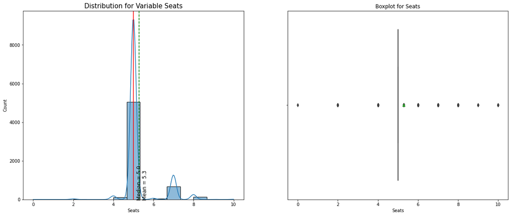

```python
checkDistribution(dfForModel,'Seats')
```

Looking at seat's distribution we can see most of the cars are 5 seats and with some exceptions where we have 6 to 10 seater caes . In data we can see some cars with 0 seats which is strange as atlest a car will have one seat .

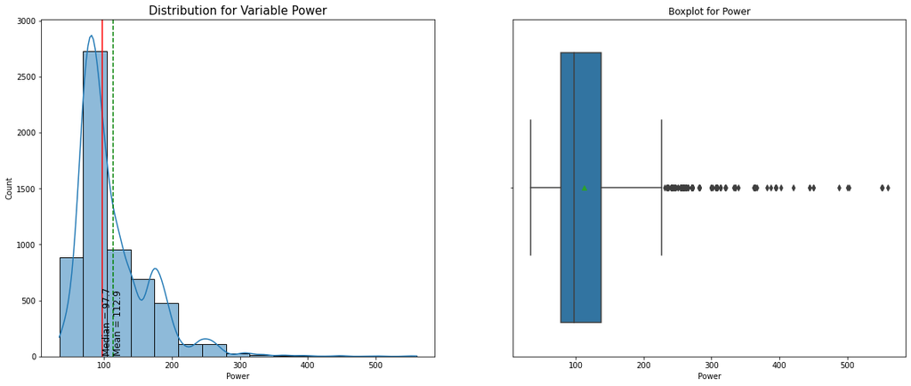

```python
checkDistribution(dfForModel,'Power')
```

Power Data is right skewed with average as 112 and median around 97 but there are many outliers with Power ranging from 200 to 550

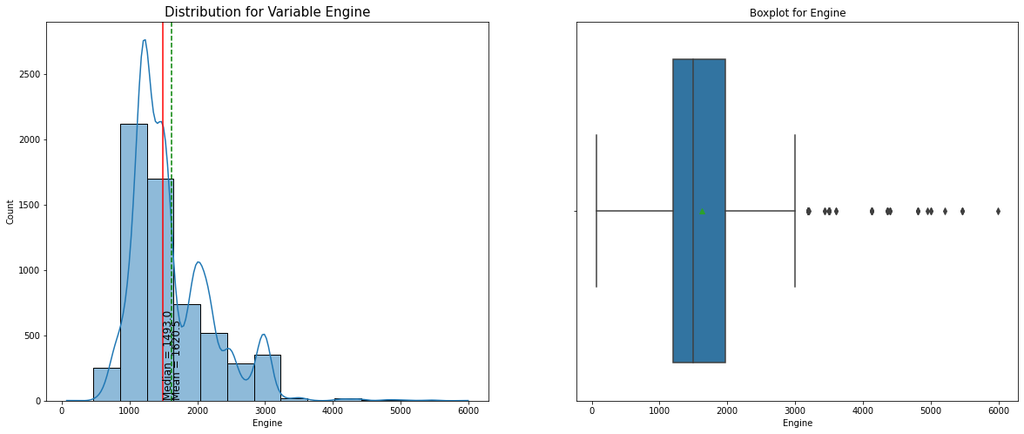

```python
checkDistribution(dfForModel,'Engine')
```

We can see Engine data is also right skewed with mean arond 1620 .and Median around 1493 .Though there are outliers but we have see that thre is strong co-rlation between price and Engine so we can not say clearly whether these points above 3000 + are real observation or some currupt data .

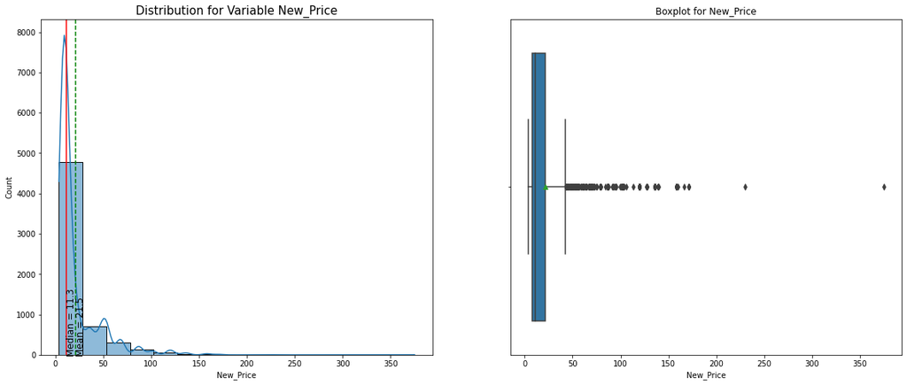

```python
checkDistribution(dfForModel,'New_Price')
```

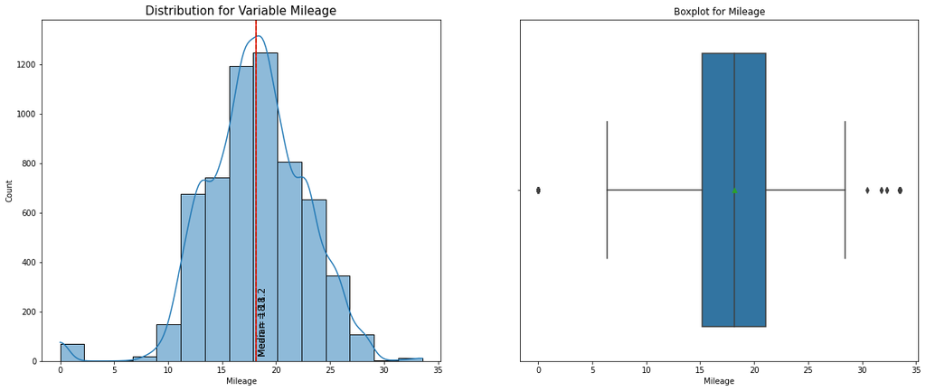

```python
checkDistribution(dfForModel,'Mileage')
```

We ca see Mileage data is normally distributed with mean and medion aroung 18 .

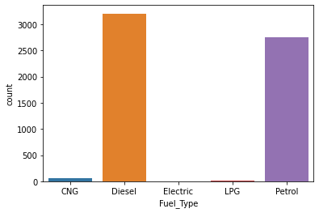

```python
sns.countplot(data=dfForModel,x='Fuel_Type')
```

We can see in given Data set maximum cars are Diesel and Petol cars and very few CNG , LPG , Electric Type .

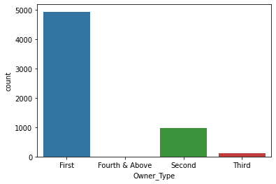

```python
sns.countplot(data=dfForModel,x='Owner_Type')
```

Most of the cars Sold are 1st hand used cars and least are thrid and forth .

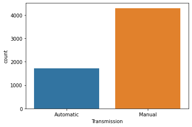

```python
sns.countplot(data=dfForModel,x='Transmission')
```

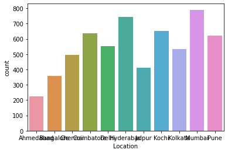

```python
sns.countplot(data=dfForModel,x='Location')
```

# Bivariate Analysis

```python
dfForModel.info()
```

```
<class 'pandas.core.frame.DataFrame'>
Int64Index: 6019 entries, 0 to 6018
Data columns (total 14 columns):
 #   Column                 Non-Null Count  Dtype
---  ------                 --------------  -----
 0   Location               6019 non-null   category
 1   Fuel_Type              6019 non-null   category
 2   Transmission           6019 non-null   category
 3   Owner_Type             6019 non-null   category
 4   Mileage                6019 non-null   float64
 5   Engine                 6019 non-null   float64
 6   Power                  6019 non-null   float64
 7   Seats                  6019 non-null   float64
 8   New_Price              6019 non-null   float64
 9   Price                  6019 non-null   float64
 10  CompanyName_revised    6019 non-null   object
 11  Model_revised          6019 non-null   object
 12  Age                    6019 non-null   int64
 13  Kilometers_Driven_log  6019 non-null   float64
dtypes: category(4), float64(7), int64(1), object(2)
memory usage: 670.7+ KB
```

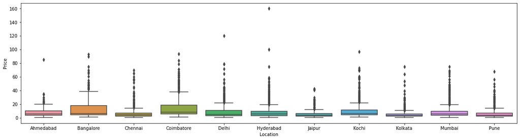

```python
plt.figure(figsize=(20, 5))
sns.boxplot(x="Location", y="Price", data=dfForModel)
plt.show()
```

In Banglore and Coimbatore cars are sold at higher price than other cities . Cars are sold at cheaper rate in KolKata , Chennai and Jiapur as compared to other location

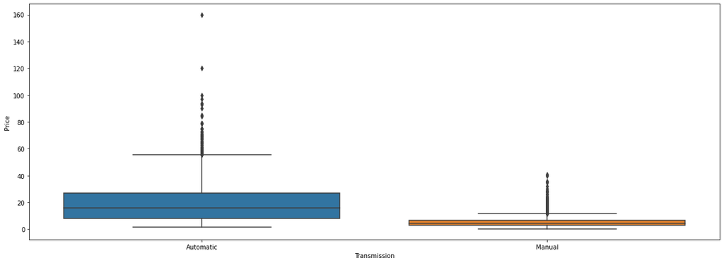

```python
plt.figure(figsize=(20, 7))
sns.boxplot(x="Transmission", y="Price", data=dfForModel)
plt.show()
```

Automatic cars are sold at much higher price than manual

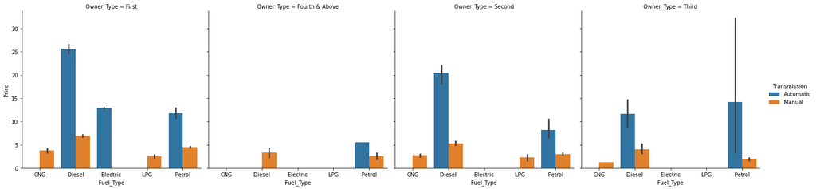

```python
sns.catplot(data=dfForModel,x="Fuel_Type",y="Price",hue="Transmission",col="Owner_Type",kind="bar")
```

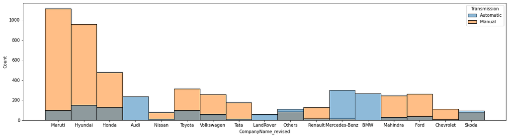

```python
plt.figure(figsize=(20, 5))
sns.histplot(data=dfForModel,x="CompanyName_revised", hue= "Transmission",bins =10)
plt.show()
```

We can in terms of count most of the cars in data set are of Company Maruti wih Transmission type as Manual .

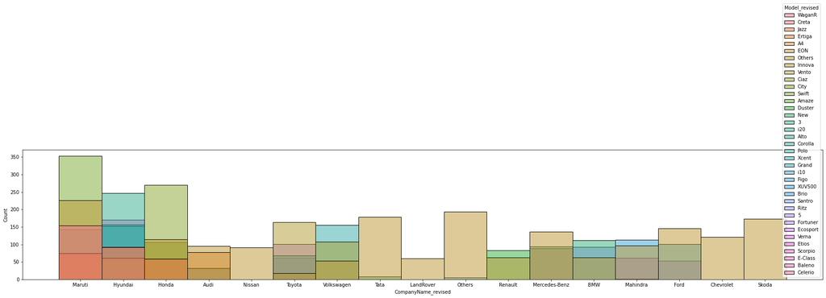

```python
plt.figure(figsize=(30, 5))
sns.histplot(data=dfForModel,x="CompanyName_revised", hue= "Model_revised",bins =20)
plt.show()
```

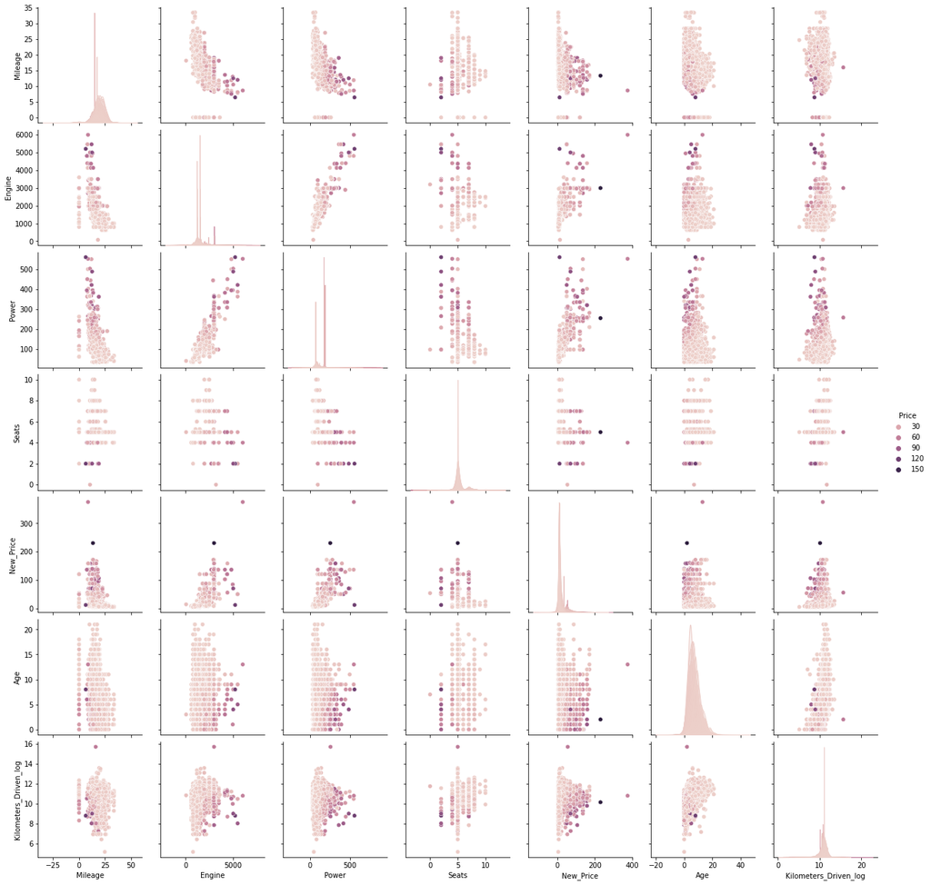

```python
sns.pairplot(data=dfForModel,hue="Price")
```

# Variable Transformation( Dummy Variable Creation)

```python
#  Create Copy of Data Frame as we will be creating  now dummy variables for categorical columns and Company and Model
finaldata=dfForModel.copy()
```

```python
 #Our Outcome depedant variable is Price hence let's drop it from X  and Take price in Depedant i.e Y variable

# I checked model performance by removing differnt columns
y = finaldata["Price"]
X = finaldata.drop(["Price"], axis=1)
#X = finaldata.drop(["Price","Model_revised"], axis=1)
#X = finaldata.drop(["Price","Model_revised" ,"CompanyName_revised"], axis=1)
```

```python
#We will have to create Dummy variables for Location ,Fuel_Type,Transmission , Owener_Type , CompanyName_revised and Model_revised .
#All these columns are of type Cateogry and Object
X = pd.get_dummies(
    X,
    columns=X.select_dtypes(include=["object", "category"]).columns.tolist(),
    drop_first=True,
)
```

# Model Developement

```python
## Let us Split Data set into Training Test set
from sklearn.model_selection import train_test_split

x_train, x_test, y_train, y_test = train_test_split(X, y, test_size=0.3, random_state=1)
```

```python
# Fit Linear Model
linear_reg_model=LinearRegression()
linear_reg_model=LinearRegression().fit(x_train,y_train)
```

```python
# Predicting for Train data  using Training Indepedant Variables
TrainPredict=linear_reg_model.predict(x_train)
```

```python
# Let us check  R2 score for training ( in sample ) data set
Traingscore =linear_reg_model.score(x_train, y_train)
```

```python
# Predicting for Test data  using Test Data Indepedant Variables
TestDataPredict=linear_reg_model.predict(x_test)
```

```python
# Let us check RMSE for testing ( out off sample)data set
Testingcore=linear_reg_model.score(x_test, y_test)
```

```python
## calculate Mean Absolute Percetage error
mape_train=np.mean(np.abs(y_train - TrainPredict) / y_train) * 100
```

```python
## calculate Mean Absolute Percetage error
mape_test=np.mean(np.abs(y_test - TestDataPredict) / y_test) * 100
```

```python
print(f'Traing Model Score {Traingscore}')
print(f'Mean Absolute Percetage error in Training {mape_train}')
print(f'Traing Model Score {Testingcore}')
print(f'Mean Absolute Percetage error in Testing {mape_test}')
```

```
Traing Model Score 0.7855521206077025
Mean Absolute Percetage error in Training 53.21521283891044
Traing Model Score 0.8134472025405538
Mean Absolute Percetage error in Testing 50.56223538806641
```

```python
# Let us see if adding interaction terms can improve performace and
#at what cost

#from sklearn.preprocessing import PolynomialFeatures
#from sklearn import linear_model

#poly = PolynomialFeatures(degree=2, interaction_only=True)
#x_train2 = poly.fit_transform(x_train)
#x_test2 = poly.fit_transform(x_test)
#poly_clf = linear_model.LinearRegression()
#poly_clf.fit(x_train2, y_train)
#y_pred = poly_clf.predict(x_test2)
```

```python
#print(f'Score for Traing Post adding interaction terms {poly_clf.score(x_train2, y_train)}')
#print(f'Score for Traing Post adding interaction terms {poly_clf.score(x_test2, y_test)}')
#print(x_train.shape)
#print(x_train2.shape)
```

# Observations :

# Conclusion

1. We could see that we could predict selling Price of used cars with R2 rate 0.81 .
2. During this process we observeed that Engine ,Power and price of new car have high co-relation with Price of old cars
3. We added Transformations for Location ,trnasmission ,KM, Fuel type as they also have substancial influce on predicting sell value .
4. We have done this analysis with limited data with additional data we can improve this model performance better .